# Analyse Factorielle des Correspondances Multiples (AFCM ou ACM)

Mastère ESD - Introduction au Machine Learning

FX Jollois

# Que veut-on faire ?

- Décrire et/ou résumer l’information contenue dans les données
  - Sans formuler d’hypothèses au préalable
- Tableau individus $\times$ variables **continues**
  - On connaît : **ACP**
- Table de contingence de deux variables
  - On connaît : **AFC**
- Tableau individus $\times$ variables **qualitatives**
  - **ACM**

## Problème et objectifs

- Visualiser les ressemblances entre les modalités d’une même variable
- Exploiter les ressources de la représentation simultanée pour analyser les liens entre plusieurs variables

# Tableau disjonctif complet

Transformation de la table des modalités pour n’avoir que des indicatrices **binaires**

| vars a | vars b | vars c |
| --- | --- | --- |
| 3 | 1 | 2 |
| 3 | 2 | 3 |
| 1 | 2 | 1 |
| 2 | 2 | 2 |
| 1 | 1 | 4 |
| 1 | 1 | 4 |
| 3 | 2 | 3 |
| 3 | 1 | 1 |
| 1 | 2 | 1 |
| 2 | 1 | 2 |

| a a1 | a a2 | a a3 | b b1 | b b2 | c c1 | c c2 | c c3 | c c4 |
| --- | --- | --- | --- | --- | --- | --- | --- | --- |
| 0 | 0 | 1 | 1 | 0 | 0 | 1 | 0 | 0 |
| 0 | 0 | 1 | 0 | 1 | 0 | 0 | 1 | 0 |
| 1 | 0 | 0 | 0 | 1 | 1 | 0 | 0 | 0 |
| 0 | 1 | 0 | 0 | 1 | 0 | 1 | 0 | 0 |
| 1 | 0 | 0 | 1 | 0 | 0 | 0 | 0 | 1 |
| 1 | 0 | 0 | 1 | 0 | 0 | 0 | 0 | 1 |
| 0 | 0 | 1 | 0 | 1 | 0 | 0 | 1 | 0 |
| 0 | 0 | 1 | 1 | 0 | 1 | 0 | 0 | 0 |
| 1 | 0 | 0 | 0 | 1 | 1 | 0 | 0 | 0 |
| 0 | 1 | 0 | 1 | 0 | 0 | 1 | 0 | 0 |

# Tableau de Burt

Décompte des **présences conjointes** des modalités des variables

| a a1 | a a2 | a a3 | b b1 | b b2 | c c1 | c c2 | c c3 | c c4 |
| --- | --- | --- | --- | --- | --- | --- | --- | --- |
| 0 | 0 | 1 | 1 | 0 | 0 | 1 | 0 | 0 |
| 0 | 0 | 1 | 0 | 1 | 0 | 0 | 1 | 0 |
| 1 | 0 | 0 | 0 | 1 | 1 | 0 | 0 | 0 |
| 0 | 1 | 0 | 0 | 1 | 0 | 1 | 0 | 0 |
| 1 | 0 | 0 | 1 | 0 | 0 | 0 | 0 | 1 |
| 1 | 0 | 0 | 1 | 0 | 0 | 0 | 0 | 1 |
| 0 | 0 | 1 | 0 | 1 | 0 | 0 | 1 | 0 |
| 0 | 0 | 1 | 1 | 0 | 1 | 0 | 0 | 0 |
| 1 | 0 | 0 | 0 | 1 | 1 | 0 | 0 | 0 |
| 0 | 1 | 0 | 1 | 0 | 0 | 1 | 0 | 0 |

|  |  | a a1 | a a2 | a a3 | b b1 | b b2 | c c1 | c c2 | c c3 | c c4 |
| --- | --- | --- | --- | --- | --- | --- | --- | --- | --- | --- |
| a | a1 | 4 | 0 | 0 | 2 | 2 | 2 | 0 | 0 | 2 |
|  | a2 | 0 | 2 | 0 | 1 | 1 | 0 | 2 | 0 | 0 |
|  | a3 | 0 | 0 | 4 | 2 | 2 | 1 | 1 | 2 | 0 |
| b | b1 | 2 | 1 | 2 | 5 | 0 | 1 | 2 | 0 | 2 |
|  | b2 | 2 | 1 | 2 | 0 | 5 | 2 | 1 | 2 | 0 |
| c | c1 | 2 | 0 | 1 | 1 | 2 | 3 | 0 | 0 | 0 |
|  | c2 | 0 | 2 | 1 | 2 | 1 | 0 | 3 | 0 | 0 |
|  | c3 | 0 | 0 | 2 | 0 | 2 | 0 | 0 | 2 | 0 |
|  | c4 | 2 | 0 | 0 | 2 | 0 | 0 | 0 | 0 | 2 |

# Principe

Utiliser le tableau disjonctif complet comme une table de contingence particulière

- Totaux en ligne, identiques et égaux au nombre de variables
- Totaux en colonne, correspondant au nombre d’individus ayant chaque modalité
- Réalisation de l’ACP avec la métrique du $\chi^2$ comme pour l’AFC

Utiliser le tableau de Burt

- Réalisation de l’AFC directement sur ce tableau

Dans tous les cas

> **Interprétation longue et délicate**

# Informations

- Nombre de valeurs propres = $m - p$
  - $m$ : nombre de modalités
  - $p$ : nombre de variables
- Somme des valeurs propres = $(m - p) / p$
- Caractéristique de l’ACM :
  - faible part de variance expliquée sur les premiers axes
- Choix du nombre de valeurs propres :
  - au moins 5
  - généralement la moitié des axes
  - recherche d’un palier important de la part de variance expliquée

# Modalités rares

Modalités avec un effectif faible : $< 2\%$ (par exemple)

- **Problème** :
  - poids importants dans le calcul
  - axes fortement influencés par elles
  - analyse faussée
- **Solution** :
  - regrouper avec d’autres modalités, si cela a du sens
  - les exclure du calcul
  - dans certains outils, on parle d’*apurement*
    - ventilation aléatoire des effectifs dans les autres modalités

# Interprétation

### Contributions

- Idem que l’ACP et l’AFC
- Recherche des modalités avec une contribution $> \frac{100}{m}$

### Qualité de représentation

Idem que pour l’ACP.

### Variables supplémentaires

Possibilité d’ajouter des variables qualitatives et quantitatives illustratives

# Exemple simple

Etude sur des enfants dans une école primaire, ayant subi une intoxication alimentaire.

| Age | Time | Sick | Sex | Nausea | Vomiting | Abdominals | Fever | Diarrhae | Potato | Fish | Mayo | Courgette | Cheese | Icecream |
| --- | --- | --- | --- | --- | --- | --- | --- | --- | --- | --- | --- | --- | --- | --- |
| 9 | 22 | y | F | y | n | y | y | y | y | y | y | y | y | y |
| 5 | 0 | n | F | n | n | n | n | n | y | y | y | y | n | y |
| 6 | 16 | y | F | n | y | y | y | y | y | y | y | y | y | y |
| 9 | 0 | n | F | n | n | n | n | n | y | y | n | y | y | y |
| 7 | 14 | y | M | n | y | y | y | y | y | y | y | y | y | y |
| 72 | 9 | y | M | n | n | y | y | y | y | n | y | y | y | y |
| 5 | 16 | y | F | n | y | y | y | y | y | y | y | y | y | y |
| 10 | 8 | y | F | y | y | y | y | y | y | y | y | y | y | y |
| 5 | 20 | y | M | y | n | y | y | y | y | y | y | y | y | y |
| 11 | 12 | y | M | n | y | n | y | y | y | y | y | y | y | y |
| 7 | 17 | y | F | y | y | y | y | y | y | y | y | y | y | y |
| 10 | 16 | y | F | n | y | y | n | n | y | y | y | y | y | y |
| 36 | 19 | y | F | n | n | y | y | y | y | y | y | y | y | y |
| 9 | 0 | n | F | n | n | n | n | n | y | y | n | y | y | y |
| 8 | 0 | n | M | n | n | n | n | n | y | y | n | y | n | y |
| 6 | 6 | y | F | n | y | y | y | y | y | y | y | y | y | y |
| 7 | 10 | y | M | n | y | y | y | y | y | y | y | y | n | y |
| 5 | 15 | y | M | y | y | y | y | y | y | y | y | y | y | y |
| 11 | 14 | y | F | n | y | y | y | y | y | y | y | y | y | y |
| 11 | 0 | n | F | n | n | n | n | n | y | y | n | y | y | y |
| 10 | 18 | y | M | n | n | y | y | y | y | y | y | y | y | y |
| 8 | 14 | y | F | n | n | y | y | y | y | y | y | y | y | n |
| 8 | 21 | y | F | n | y | y | y | y | y | y | y | n | y | y |
| 11 | 13 | y | M | n | y | y | n | y | y | y | y | y | y | y |
| 45 | 10 | y | F | n | n | y | y | y | y | y | y | y | n | y |
| 9 | 0 | n | M | n | n | n | n | n | y | y | y | y | y | y |
| 5 | 12 | y | F | n | y | y | y | n | y | y | y | y | y | y |
| 85 | 9 | y | M | n | y | y | y | y | y | y | n | n | y | y |
| 88 | 0 | n | F | n | n | n | n | n | y | y | y | y | y | y |
| 79 | 17 | y | F | y | y | y | y | y | y | y | y | y | y | y |
| 9 | 9 | y | F | n | n | y | y | y | y | y | n | y | y | y |
| 6 | 0 | n | M | n | n | n | n | n | y | y | n | y | n | y |
| 8 | 0 | n | F | n | n | n | n | n | y | y | y | y | y | y |
| 8 | 0 | n | M | n | n | n | n | n | y | y | y | y | y | y |
| 7 | 15 | y | F | y | n | y | y | y | n | y | y | y | y | y |
| 9 | 19 | y | M | y | y | y | y | y | y | y | y | y | y | y |
| 9 | 11 | y | M | y | n | y | n | y | n | y | y | y | y | y |
| 6 | 0 | n | F | n | n | n | n | n | y | y | y | n | n | y |
| 5 | 17 | y | M | n | n | y | y | y | n | y | y | y | y | y |
| 6 | 16 | y | M | y | y | y | y | y | y | y | y | y | y | y |
| 4 | 12 | y | M | y | n | y | y | y | y | y | y | y | y | y |
| 7 | 0 | n | M | n | n | n | n | n | y | y | y | y | y | y |
| 82 | 20 | y | F | n | n | y | y | y | y | y | y | y | y | y |
| 5 | 4 | y | F | y | y | y | y | y | y | y | y | n | y | n |
| 5 | 20 | y | M | n | y | y | y | y | y | y | y | n | y | y |
| 6 | 16 | y | M | n | n | y | y | y | y | y | y | y | y | y |
| 10 | 0 | n | M | n | n | n | n | n | y | y | n | y | y | n |
| 83 | 0 | n | M | n | n | n | n | n | y | y | y | y | y | y |
| 8 | 0 | n | F | n | n | n | n | n | y | y | y | y | y | y |
| 7 | 22 | y | F | n | n | y | y | y | y | y | y | y | y | y |
| 10 | 0 | n | M | n | n | n | n | n | y | y | n | y | y | y |
| 11 | 17 | y | M | n | n | y | y | y | y | y | y | y | y | y |
| 6 | 0 | n | F | n | n | n | n | n | y | y | n | y | n | n |
| 10 | 19 | y | M | n | y | y | y | n | y | y | y | y | y | y |
| 7 | 14 | y | M | n | y | y | y | y | y | y | y | y | y | y |

# Variables

- 2 variables quantitatives : `Age`, `Time`
- 1 variable *cible* : `Sick`
- 1 variable qualitative informative : `Sex`
- 5 variables binaires sur les symptômes : `Nausea`, `Vomiting`, `Abdominals`, `Fever`, `Diarrhae`
- 6 variables binaires sur les aliments consommés : `Potato`, `Fish`, `Mayo`, `Courgette`, `Cheese`, `Icecream`

```
##       Age             Time           Sick           Sex       Nausea
##  Min.   : 4.00   Min.   : 0.00   Length:55          F:28   Length:55
##  1st Qu.: 6.00   1st Qu.: 0.00   Class :character   M:27   Class :character
##  Median : 8.00   Median :12.00   Mode  :character          Mode  :character
##  Mean   :16.93   Mean   :10.16
##  3rd Qu.:10.00   3rd Qu.:16.50
##  Max.   :88.00   Max.   :22.00
##    Vomiting          Abdominals           Fever             Diarrhae
##  Length:55          Length:55          Length:55          Length:55
##  Class :character   Class :character   Class :character   Class :character
##  Mode  :character   Mode  :character   Mode  :character   Mode  :character
##
##
##
##     Potato              Fish               Mayo            Courgette
##  Length:55          Length:55          Length:55          Length:55
##  Class :character   Class :character   Class :character   Class :character
##  Mode  :character   Mode  :character   Mode  :character   Mode  :character
##
##
##
##     Cheese            Icecream
##  Length:55          Length:55
##  Class :character   Class :character
##  Mode  :character   Mode  :character
##
##
##
```

A noter : 1 modalité rare (`Fish == "n"`)

# Part de la variance expliquée

|  | Valeur propre | Variance (%) | Cumulée (%) |
| --- | --- | --- | --- |
| dim 1 | 0.34 | 33.52 | 33.52 |
| dim 2 | 0.13 | 12.91 | 46.44 |
| dim 3 | 0.11 | 10.73 | 57.17 |
| dim 4 | 0.10 | 9.59 | 66.76 |
| dim 5 | 0.08 | 7.88 | 74.64 |
| dim 6 | 0.07 | 7.11 | 81.75 |
| dim 7 | 0.06 | 6.02 | 87.77 |
| dim 8 | 0.06 | 5.58 | 93.35 |
| dim 9 | 0.04 | 4.12 | 97.47 |
| dim 10 | 0.01 | 1.30 | 98.77 |
| dim 11 | 0.01 | 1.23 | 100.00 |

# Part de la variance expliquée

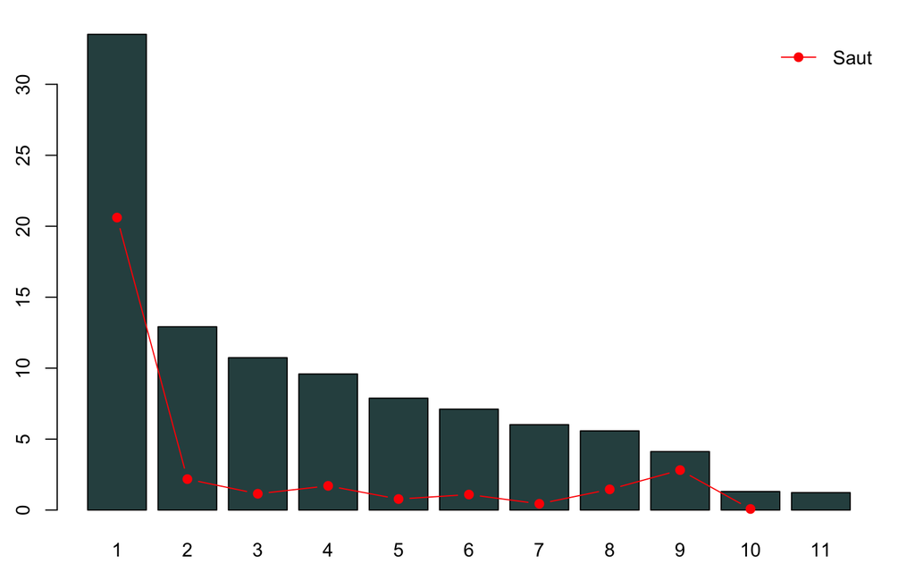

# Représentation graphique

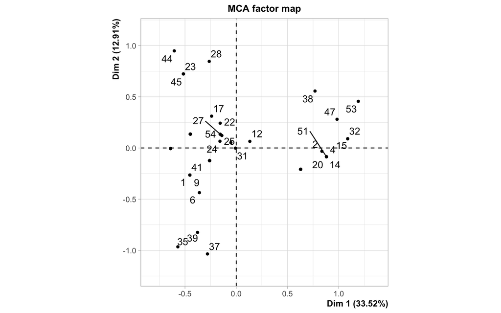

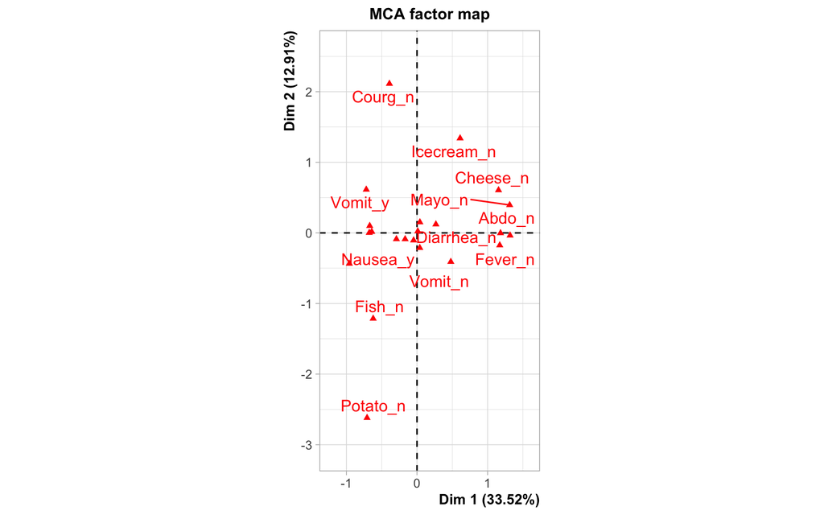

# Représentation conjointe

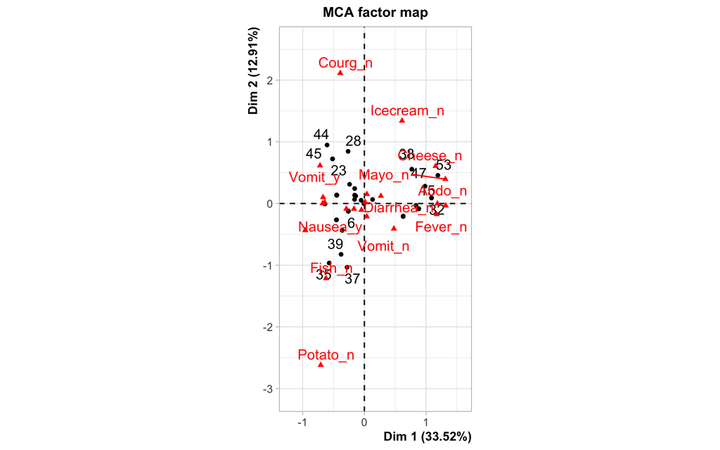

# Représentation de chaque variable séparemment

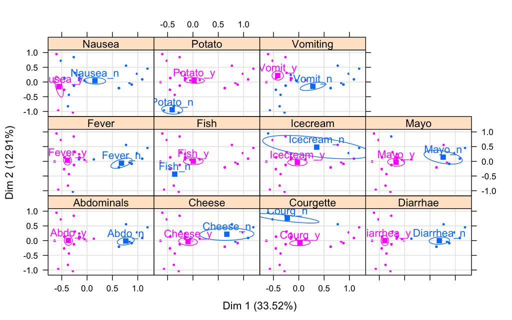

# Représentation des variables

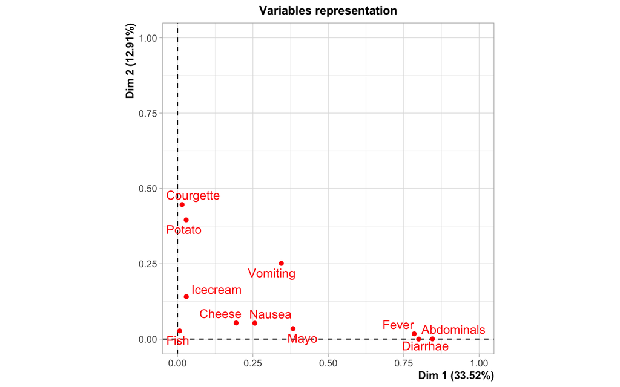

# En gardant 5 axes

# Modalités importantes (contributions)

|  | Dim.1 | Dim.2 | Dim.3 | Dim.4 | Dim.5 |
| --- | --- | --- | --- | --- | --- |
| Nausea_n | 2 | 1 | 5 | 0 | 0 |
| Nausea_y | 5 | 3 | 17 | 0 | 2 |
| Vomit_n | 4 | 7 | 0 | 4 | 0 |
| Vomit_y | 6 | 11 | 1 | 6 | 0 |
| Abdo_n | 15 | 0 | 0 | 1 | 0 |
| Abdo_y | 8 | 0 | 0 | 0 | 0 |
| Fever_n | 14 | 1 | 0 | 1 | 0 |
| Fever_y | 8 | 0 | 0 | 1 | 0 |
| Diarrhea_n | 14 | 0 | 0 | 2 | 0 |
| Diarrhea_y | 8 | 0 | 0 | 1 | 0 |
| Potato_n | 1 | 26 | 21 | 1 | 12 |
| Potato_y | 0 | 2 | 1 | 0 | 1 |
| Fish_n | 0 | 2 | 21 | 53 | 0 |
| Fish_y | 0 | 0 | 0 | 1 | 0 |
| Mayo_n | 8 | 2 | 3 | 2 | 2 |
| Mayo_y | 2 | 0 | 1 | 1 | 0 |
| Courg_n | 0 | 29 | 4 | 1 | 13 |
| Courg_y | 0 | 3 | 0 | 0 | 1 |
| Cheese_n | 5 | 3 | 1 | 2 | 41 |
| Cheese_y | 1 | 0 | 0 | 0 | 6 |
| Icecream_n | 1 | 9 | 23 | 20 | 18 |
| Icecream_y | 0 | 1 | 2 | 2 | 1 |

# Individus importants (contributions)

| Dim.1 | Dim.2 | Dim.3 | Dim.4 | Dim.5 |
| --- | --- | --- | --- | --- |
| 1 | 1 | 0 | 0 | 0 |
| 4 | 0 | 0 | 0 | 6 |
| 1 | 0 | 1 | 0 | 0 |
| 4 | 0 | 0 | 0 | 1 |
| 1 | 0 | 1 | 0 | 0 |
| 1 | 3 | 25 | 56 | 0 |
| 1 | 0 | 1 | 0 | 0 |
| 2 | 0 | 0 | 1 | 1 |
| 1 | 1 | 0 | 0 | 0 |
| 0 | 0 | 1 | 1 | 0 |
| 2 | 0 | 0 | 1 | 1 |
| 0 | 0 | 1 | 2 | 0 |
| 0 | 0 | 0 | 0 | 0 |
| 4 | 0 | 0 | 0 | 1 |
| 6 | 0 | 0 | 0 | 4 |
| 1 | 0 | 1 | 0 | 0 |
| 0 | 1 | 0 | 0 | 8 |
| 2 | 0 | 0 | 1 | 1 |
| 1 | 0 | 1 | 0 | 0 |
| 4 | 0 | 0 | 0 | 1 |
| 0 | 0 | 0 | 0 | 0 |
| 0 | 1 | 3 | 7 | 6 |
| 1 | 7 | 0 | 0 | 3 |
| 0 | 0 | 1 | 1 | 0 |
| 0 | 0 | 0 | 1 | 9 |
| 2 | 1 | 0 | 1 | 0 |
| 0 | 0 | 1 | 1 | 0 |
| 0 | 10 | 0 | 0 | 1 |
| 2 | 1 | 0 | 1 | 0 |
| 2 | 0 | 0 | 1 | 1 |
| 0 | 0 | 0 | 1 | 0 |
| 6 | 0 | 0 | 0 | 4 |
| 2 | 1 | 0 | 1 | 0 |
| 2 | 1 | 0 | 1 | 0 |
| 2 | 13 | 11 | 0 | 3 |
| 2 | 0 | 0 | 1 | 1 |
| 0 | 15 | 12 | 0 | 3 |
| 3 | 4 | 0 | 0 | 20 |
| 1 | 10 | 4 | 1 | 5 |
| 2 | 0 | 0 | 1 | 1 |
| 1 | 1 | 0 | 0 | 0 |
| 2 | 1 | 0 | 1 | 0 |
| 0 | 0 | 0 | 0 | 0 |
| 2 | 13 | 14 | 4 | 2 |
| 1 | 7 | 0 | 0 | 3 |
| 0 | 0 | 0 | 0 | 0 |
| 5 | 1 | 5 | 4 | 13 |
| 2 | 1 | 0 | 1 | 0 |
| 2 | 1 | 0 | 1 | 0 |
| 0 | 0 | 0 | 0 | 0 |
| 4 | 0 | 0 | 0 | 1 |
| 0 | 0 | 0 | 0 | 0 |
| 8 | 3 | 7 | 7 | 0 |
| 0 | 0 | 1 | 1 | 0 |
| 1 | 0 | 1 | 0 | 0 |

# Variables supplémentaires

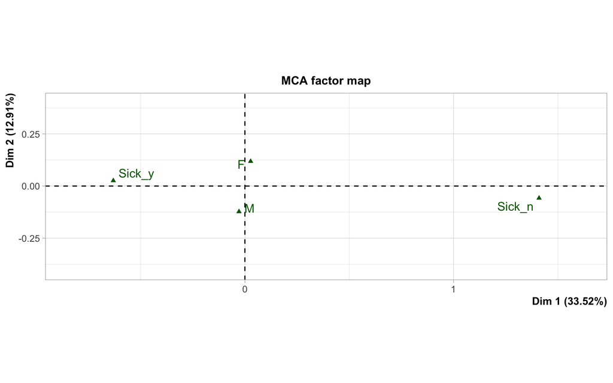

# Avec modalité rare

2 possibilités :

- on fixe les modalités à exclure (par exemple `Fish == n`)
- on fixe un seuil de ventilation (par exemple 2%)

Dans notre cas, nous avons une modalité rare pour une variable à 2 modalités. L’exclure n’est pas utile, il est préférable de placer la variable `Fish` en illustrative.

> Qu’est-ce que ca change ?

# Part de la variance expliquée

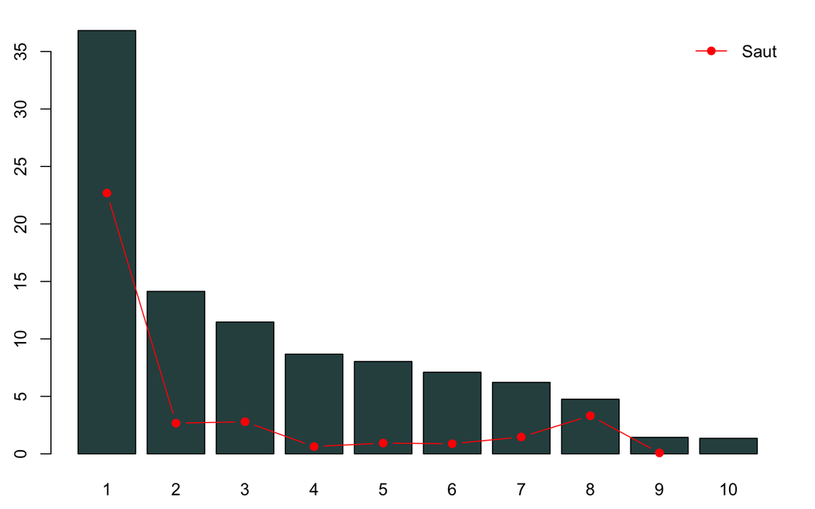

# Les 5 premiers axes

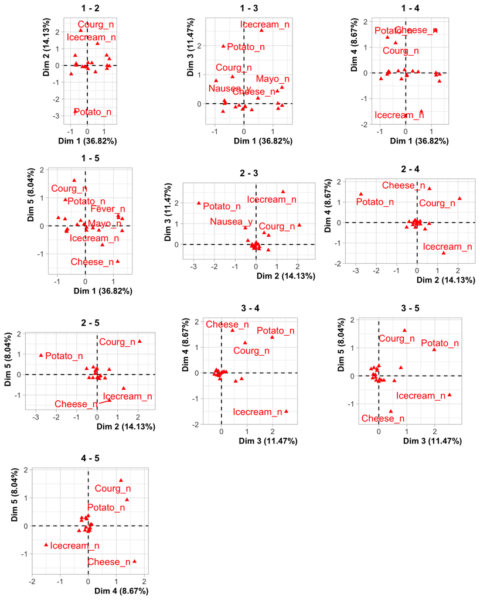

# Variables supplémentaires

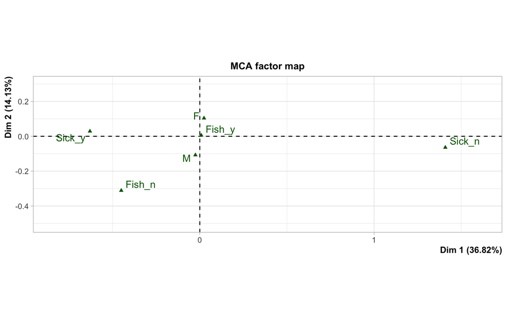